# Regression Modeling Features from HBO Series Game of Thrones

#### **Part H**: *(5 points) Draw the residual plot and QQ-plot. Comment on the model assumptions based on these two plots.*

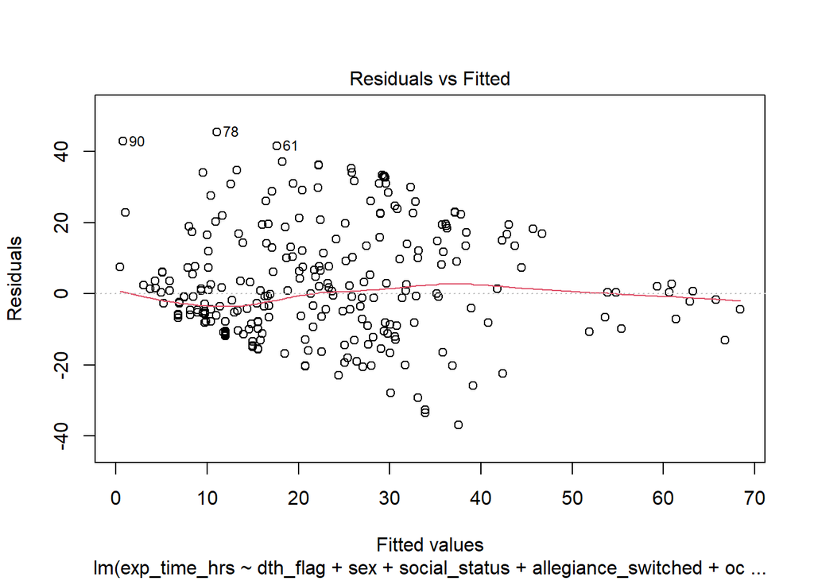

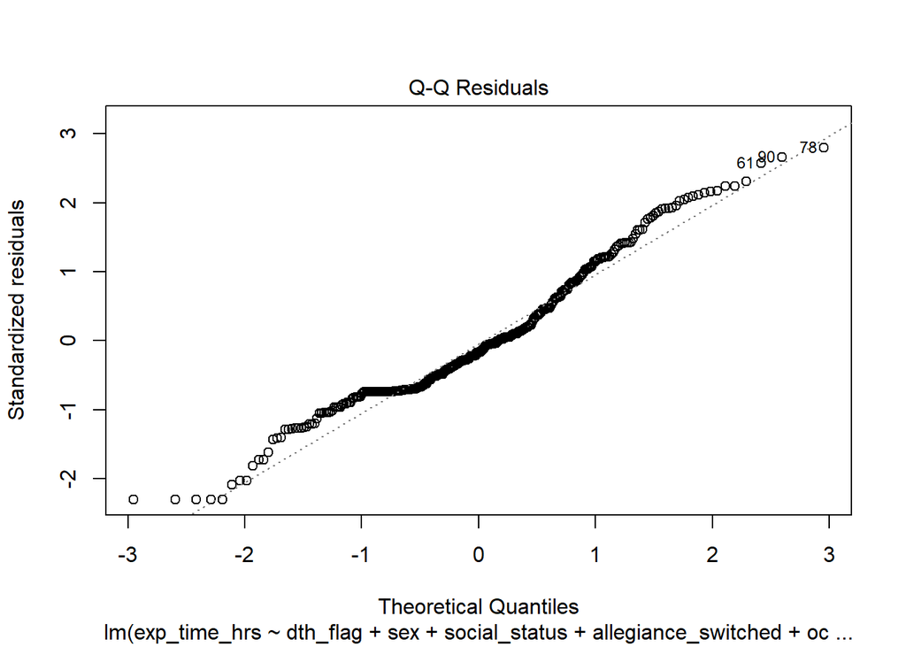

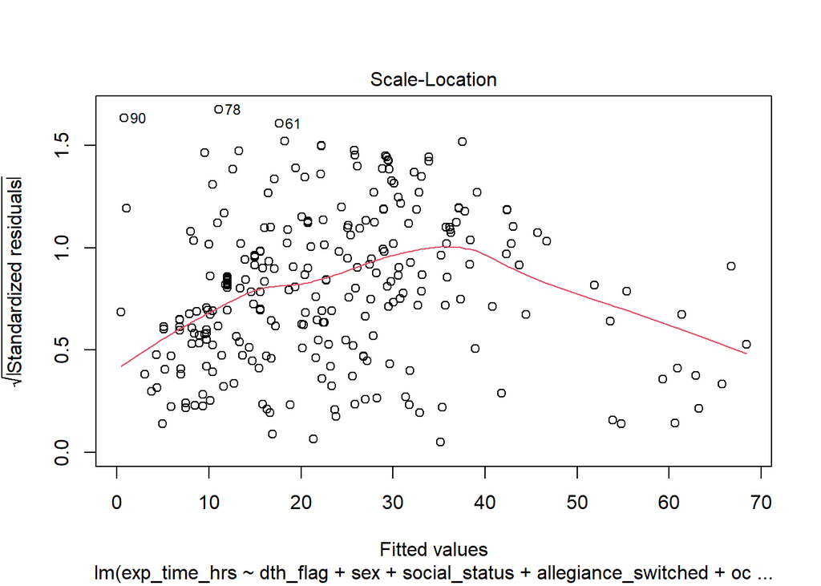

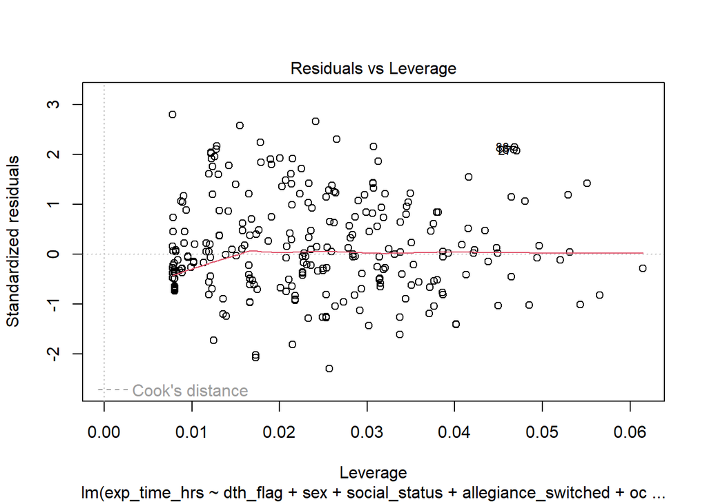

```r
plot(reg_1)
```

```r
shapiro.test(reg_1$residuals)
```

```
##
##  Shapiro-Wilk normality test
##
## data:  reg_1$residuals
## W = 0.96696, p-value = 1.249e-06
```

```r
bptest(reg_1)
```

```
##
##  studentized Breusch-Pagan test
##
## data:  reg_1
## BP = 23.245, df = 6, p-value = 0.0007184
```

**SOLUTION:** As observed from the graphs, the assumptions of normal and homogeneous residuals have been violated. That is, both tests presented p-value below 0.05 thus rejection of the hypothesis of normal residuals as well as homogeneous residuals.

#### **Part I**: *(5 points) What are the values of R-square and adjusted R-square for this model? Explain how these two quantities can be used.*

**SOLUTION:** As seen from the output, the value for R² is 0.3937 and for the Adj. R² the value is 0.3820. The R² refers to the overall explanation of the variance in survival time based on the variations in each predictor variable (39.37%). The Adj. R² value means the same, however, it adjusts the value based on the number of predictors that the model contains (38.20%).

#### **Part K**: *(5 points) One student fits a different linear regression model with two variables (sex and occupation) dropped. Compare this model with the model fitted in the previous questions. What one is better? Report test statistic, degrees of freedom, and p-value.*

```r
reg_2 <- lm(exp_time_hrs~dth_flag+social_status+allegiance_switched+log(prominence), data=new_data)
summ(reg_2, digits = 4, confint = TRUE)
```

| Observations | 317 |
| --- | --- |
| Dependent variable | exp_time_hrs |
| Type | OLS linear regression |

| F(4,312) | 48.2586 |
| --- | --- |
| R² | 0.3822 |
| Adj. R² | 0.3743 |

|  | Est. | 2.5% | 97.5% | t val. | p |
| --- | --- | --- | --- | --- | --- |
| (Intercept) | 17.3792 | 13.4846 | 21.2738 | 8.7802 | 0.0000 |
| dth_flag2 | 22.2188 | 18.0096 | 26.4280 | 10.3863 | 0.0000 |
| social_status2 | -5.7623 | -9.9840 | -1.5406 | -2.6856 | 0.0076 |
| allegiance_switched2 | 13.4933 | 8.1293 | 18.8573 | 4.9496 | 0.0000 |
| log(prominence) | 5.3811 | 3.1040 | 7.6582 | 4.6497 | 0.0000 |

Standard errors: OLS

```r
anova(reg_2,reg_1)
```

```
## Analysis of Variance Table
##
## Model 1: exp_time_hrs ~ dth_flag + social_status + allegiance_switched +
##     log(prominence)
## Model 2: exp_time_hrs ~ dth_flag + sex + social_status + allegiance_switched +
##     occupation + log(prominence)
##   Res.Df   RSS Df Sum of Sq      F  Pr(>F)
## 1    312 83769
## 2    310 82211  2    1557.9 2.9372 0.05449 .
## ---
## Signif. codes:  0 '***' 0.001 '**' 0.01 '*' 0.05 '.' 0.1 ' ' 1
```

**SOLUTION:** Applying the anova function to compare the models, we notice that reducing the model did not make any statistically significantly different than the model we already had, F = 2.9372, p = 0.05449. Also, in terms of R² or Adj. R² values we notice that this new model actually has lower R² and Adj. R² values compared to the first model.

#### **Part L**: *(5 points) Conduct variable selection using the stepwise selection procedure. What is the final model?*

```r
step.model <- stepAIC(reg_1, direction = "both",
                      trace = FALSE)
summ(step.model, digits=4)
```

| Observations | 317 |
| --- | --- |
| Dependent variable | exp_time_hrs |
| Type | OLS linear regression |

| F(5,311) | 39.8166 |
| --- | --- |
| R² | 0.3903 |
| Adj. R² | 0.3805 |

|  | Est. | S.E. | t val. | p |
| --- | --- | --- | --- | --- |
| (Intercept) | 16.0362 | 2.0777 | 7.7181 | 0.0000 |
| dth_flag2 | 22.2857 | 2.1289 | 10.4682 | 0.0000 |
| social_status2 | -8.3620 | 2.4898 | -3.3585 | 0.0009 |
| allegiance_switched2 | 12.7304 | 2.7386 | 4.6486 | 0.0000 |
| occupation2 | 4.7691 | 2.3499 | 2.0295 | 0.0433 |
| log(prominence) | 5.4956 | 1.1529 | 4.7667 | 0.0000 |

Standard errors: OLS

#### **Part M**: *(5 points) One student suggests that we should consider two-factor interactions. Based on the model selected using stepwise in the previous question, add all two-factor interactions among the variable selected. Report the result of the significance test for this model (test statistic, degrees of freedom, p-value, and conclusion).*

```r
reg_3 <- lm(exp_time_hrs~dth_flag*social_status*allegiance_switched*occupation*log(prominence), data=new_data)
summ(reg_3, digits = 4, confint = TRUE)
```

| Observations | 317 |
| --- | --- |
| Dependent variable | exp_time_hrs |
| Type | OLS linear regression |

| F(29,287) | 10.2803 |
| --- | --- |
| R² | 0.5095 |
| Adj. R² | 0.4599 |

|  | Est. | 2.5% | 97.5% | t val. | p |
| --- | --- | --- | --- | --- | --- |
| (Intercept) | 20.1147 | 14.5173 | 25.7120 | 7.0732 | 0.0000 |
| dth_flag2 | 1.4145 | -8.8176 | 11.6467 | 0.2721 | 0.7857 |
| social_status2 | -9.1278 | -18.2529 | -0.0026 | -1.9688 | 0.0499 |
| allegiance_switched2 | 1.6089 | -8.8909 | 12.1088 | 0.3016 | 0.7632 |
| occupation2 | -5.1534 | -16.6197 | 6.3130 | -0.8846 | 0.3771 |
| log(prominence) | 12.6621 | 5.5237 | 19.8004 | 3.4913 | 0.0006 |
| dth_flag2:social_status2 | 13.1733 | -5.0767 | 31.4234 | 1.4207 | 0.1565 |
| dth_flag2:allegiance_switched2 | 24.5789 | -245.0790 | 294.2368 | 0.1794 | 0.8577 |
| social_status2:allegiance_switched2 | 26.0121 | -4.2482 | 56.2724 | 1.6919 | 0.0917 |
| dth_flag2:occupation2 | -8.8126 | -101.7933 | 84.1681 | -0.1866 | 0.8521 |
| social_status2:occupation2 | 3.8472 | -10.0156 | 17.7100 | 0.5462 | 0.5853 |
| allegiance_switched2:occupation2 | 25.2330 | -5.1757 | 55.6417 | 1.6333 | 0.1035 |
| dth_flag2:log(prominence) | -9.8891 | -20.3386 | 0.5604 | -1.8627 | 0.0635 |
| social_status2:log(prominence) | -1.0422 | -14.4385 | 12.3540 | -0.1531 | 0.8784 |
| allegiance_switched2:log(prominence) | 7.1070 | -4.3093 | 18.5234 | 1.2253 | 0.2215 |
| occupation2:log(prominence) | -23.4804 | -40.0881 | -6.8728 | -2.7828 | 0.0057 |
| dth_flag2:social_status2:allegiance_switched2 | -15.7146 | -114.4581 | 83.0289 | -0.3132 | 0.7543 |
| dth_flag2:social_status2:occupation2 | 19.8731 | -74.6180 | 114.3642 | 0.4140 | 0.6792 |
| dth_flag2:allegiance_switched2:occupation2 | -1.5246 | -288.1505 | 285.1013 | -0.0105 | 0.9917 |
| social_status2:allegiance_switched2:occupation2 | -51.6346 | -95.3815 | -7.8877 | -2.3231 | 0.0209 |
| dth_flag2:social_status2:log(prominence) | 0.1035 | -18.4563 | 18.6633 | 0.0110 | 0.9912 |
| dth_flag2:allegiance_switched2:log(prominence) | -1.6391 | -147.2417 | 143.9636 | -0.0222 | 0.9823 |
| social_status2:allegiance_switched2:log(prominence) | -8.2153 | -43.7661 | 27.3355 | -0.4548 | 0.6496 |
| dth_flag2:occupation2:log(prominence) | 2.5596 | -49.6709 | 54.7900 | 0.0965 | 0.9232 |
| social_status2:occupation2:log(prominence) | 16.7391 | -4.0077 | 37.4858 | 1.5881 | 0.1134 |
| allegiance_switched2:occupation2:log(prominence) | 12.4033 | -16.9369 | 41.7436 | 0.8321 | 0.4061 |
| dth_flag2:social_status2:allegiance_switched2:occupation2 | NA | NA | NA | NA | NA |
| dth_flag2:social_status2:allegiance_switched2:log(prominence) | -18.0811 | -78.2518 | 42.0895 | -0.5915 | 0.5547 |
| dth_flag2:social_status2:occupation2:log(prominence) | 4.5571 | -50.3306 | 59.4447 | 0.1634 | 0.8703 |
| dth_flag2:allegiance_switched2:occupation2:log(prominence) | 1.2519 | -155.0184 | 157.5223 | 0.0158 | 0.9874 |
| social_status2:allegiance_switched2:occupation2:log(prominence) | 12.0340 | -36.1834 | 60.2514 | 0.4912 | 0.6236 |
| dth_flag2:social_status2:allegiance_switched2:occupation2:log(prominence) | NA | NA | NA | NA | NA |

Standard errors: OLS

#### **Part N**: *(5 points) Based on the model in the previous question (main effect and two-factor interactions), conduct a variable selection using backward elimination. What is the final model?.*

```r
back.model <- stepAIC(reg_3, direction = "backward",
                      trace = FALSE)
summ(back.model, digits=4)
```

| Observations | 317 |
| --- | --- |
| Dependent variable | exp_time_hrs |
| Type | OLS linear regression |

| F(16,300) | 18.5674 |
| --- | --- |
| R² | 0.4976 |
| Adj. R² | 0.4708 |

|  | Est. | S.E. | t val. | p |
| --- | --- | --- | --- | --- |
| (Intercept) | 20.0929 | 2.6228 | 7.6609 | 0.0000 |
| dth_flag2 | 3.2944 | 4.3155 | 0.7634 | 0.4458 |
| social_status2 | -10.9572 | 4.1278 | -2.6545 | 0.0084 |
| allegiance_switched2 | 1.6180 | 4.8948 | 0.3306 | 0.7412 |
| occupation2 | -3.0537 | 5.1490 | -0.5931 | 0.5536 |
| log(prominence) | 10.9180 | 2.4371 | 4.4800 | 0.0000 |
| dth_flag2:social_status2 | 18.4145 | 4.7441 | 3.8816 | 0.0001 |
| dth_flag2:allegiance_switched2 | 8.2008 | 5.9514 | 1.3780 | 0.1692 |
| social_status2:allegiance_switched2 | 22.1323 | 12.4393 | 1.7792 | 0.0762 |
| social_status2:occupation2 | 4.1167 | 6.1390 | 0.6706 | 0.5030 |
| allegiance_switched2:occupation2 | 28.2693 | 9.7023 | 2.9137 | 0.0038 |
| dth_flag2:log(prominence) | -5.9947 | 2.3284 | -2.5747 | 0.0105 |
| social_status2:log(prominence) | -0.1379 | 3.9508 | -0.0349 | 0.9722 |
| allegiance_switched2:log(prominence) | 10.1246 | 2.5889 | 3.9107 | 0.0001 |
| occupation2:log(prominence) | -16.1471 | 4.0413 | -3.9955 | 0.0001 |
| social_status2:allegiance_switched2:occupation2 | -46.0947 | 15.4371 | -2.9860 | 0.0031 |
| social_status2:occupation2:log(prominence) | 11.2383 | 5.2266 | 2.1502 | 0.0323 |

Standard errors: OLS

### **QUESTION 2**: *(30 points) In this problem, the response is dth_flag and the predictors are sex, social_status, allegiance_switched, occupation, and the logarithm of prominence. Model the probability that a character died in the series.*

#### **Part A**: *(5 points) Fit a logistic regression model and write out the fitted regression function.*

```r
reg_4 <- glm(dth_flag~sex+social_status+allegiance_switched+occupation+log(prominence), family= "binomial", data=new_data)
summ(reg_4, digits = 4, confint = TRUE)
```

| Observations | 317 |
| --- | --- |
| Dependent variable | dth_flag |
| Type | Generalized linear model |
| Family | binomial |
| Link | logit |

| χ²(5) | 74.4282 |
| --- | --- |
| p | 0.0000 |
| Pseudo-R² (Cragg-Uhler) | 0.2855 |
| Pseudo-R² (McFadden) | 0.1778 |
| AIC | 356.0987 |
| BIC | 378.6521 |

|  | Est. | 2.5% | 97.5% | z val. | p |
| --- | --- | --- | --- | --- | --- |
| (Intercept) | 1.3196 | 0.7132 | 1.9261 | 4.2646 | 0.0000 |
| sex2 | -0.6185 | -1.2524 | 0.0155 | -1.9122 | 0.0559 |
| social_status2 | 0.0124 | -0.6926 | 0.7174 | 0.0345 | 0.9725 |
| allegiance_switched2 | -1.3424 | -2.1322 | -0.5527 | -3.3315 | 0.0009 |
| occupation2 | -0.0254 | -0.6864 | 0.6355 | -0.0754 | 0.9399 |
| log(prominence) | 1.1862 | 0.8597 | 1.5128 | 7.1204 | 0.0000 |

Standard errors: MLE

**SOLUTION:** As observed, the final model is $p = 1 / (1+exp(-(1.3196-0.6185(Male)+0.0124(Highborn)-1.3424(No Switch)-0.0254(Silk Collar)+1.1862(log(Prominence)))))$

#### **Part B**: *(5 points) Interpret the effect of switching allegiance in terms of odds ratio.*

```r
exp(coef(reg_4))
```

```
##          (Intercept)                 sex2       social_status2
##            3.7421022            0.5387645            1.0124854
## allegiance_switched2          occupation2      log(prominence)
##            0.2612141            0.9748866            3.2747690
```

#### **Part C**: *(5 points) Does the probability that a character died in the series depend on these variables? In another word, is this model significant? Report test statistic, degrees of freedom, p-value, and your conclusion.*

**SOLUTION:** As observed, statistics of the model: χ²(5) = 74.4282, p = 0.0000, Pseudo-R² (Cragg-Uhler) = 0.2855, AIC = 356.0987, BIC = 378.6521, suggest the model is significant since the p-value is smaller than the significance level.

#### **Part F**: *(5 points) One student fits a similar model with only two variables (allegiance_switched and the logarithm of prominence). Compare this model with the model fitted in the previous question. Which one is better? Report test statistic, degrees of freedom, p-value, and your conclusion.*

```r
reg_5 <- glm(dth_flag~allegiance_switched+log(prominence), family= "binomial", data=new_data)
summ(reg_5, digits = 4, confint = TRUE)
```

| Observations | 317 |
| --- | --- |
| Dependent variable | dth_flag |
| Type | Generalized linear model |
| Family | binomial |
| Link | logit |

| χ²(2) | 70.7259 |
| --- | --- |
| p | 0.0000 |
| Pseudo-R² (Cragg-Uhler) | 0.2728 |
| Pseudo-R² (McFadden) | 0.1690 |
| AIC | 353.8010 |
| BIC | 365.0777 |

|  | Est. | 2.5% | 97.5% | z val. | p |
| --- | --- | --- | --- | --- | --- |
| (Intercept) | 1.2018 | 0.8656 | 1.5380 | 7.0057 | 0.0000 |
| allegiance_switched2 | -1.4270 | -2.1950 | -0.6589 | -3.6414 | 0.0003 |
| log(prominence) | 1.2143 | 0.8906 | 1.5379 | 7.3534 | 0.0000 |

Standard errors: MLE

```r
anova(reg_5, reg_4)
```

```
## Analysis of Deviance Table
##
## Model 1: dth_flag ~ allegiance_switched + log(prominence)
## Model 2: dth_flag ~ sex + social_status + allegiance_switched + occupation +
##     log(prominence)
##   Resid. Df Resid. Dev Df Deviance Pr(>Chi)
## 1       314      347.8
## 2       311      344.1  3   3.7023   0.2955
```

**SOLUTION:** Applying the anova function to compare the models, we notice that reducing the model did not make any statistically significantly different than the model we already had, Deviance = 3.7023. Also, in terms of R² or Adj. R² values we notice that this new model has almost the same R² and Adj. R² values compared to the first model.